# Analysis on crime data in Washington D.C. Area in 2019

Lingxuan Chen, Shuai Zhang, Xuan Han

## Introduction

The main goal of this project is to analyze the crime data of Washington D.C. in 2019 and hopefully we can get some overall warnings for people live in DC about the most common types of crime and the area that has the hight cirme rate.

During this project, we will be analyzing the trend and the relationship between the types of crimes and the time range of crimes, and the types of crimes and the location of crimes. We will be predicting the types of crimes under certain condition.

### Required Tools

We are working in Python 3.7 environment for this project.

The required tools/packages for this project are:

- pandas
- numpy
- sklearn
- seaborn
- statsmodels
- matplotlib
- datetime
- folium

For better understanding of this project, please visit of pandas, numpy, etc. library before reading this project. Some links are:

- https://pandas.pydata.org/pandas-docs/stable/
- https://numpy.org/#
- https://scikit-learn.org/stable/
- https://seaborn.pydata.org/index.html
- https://python-visualization.github.io/folium/
- etc.

**Note** : for the clearity and readlity of the project, we will import the warning package and hide all warnings that appears in the during the project

This project will be containing mainly four parts:

- **1. Data Collection**
  - Collecting data
  - Data Tidying
  - Introducing basic contents of the dataset
  - Modifying data for convinence
- **2. Data Visualization**
  - Visualizing data with BIDs over times
  - Visualizing data with Wards over Maps
  - Visualizing data with Methods
- **3. Predicting homicide offense given time**
  - Predicting using Random Forest Model
- **4. Conclusion**

```python
import pandas as pd
import numpy as np
import sklearn
import seaborn as sns
import statsmodels.api as sm
import statsmodels.formula.api as smf
from sklearn import datasets as ds
from sklearn import linear_model as lm
import matplotlib.pyplot as plt
from datetime import datetime
from datetime import timedelta
import folium
from folium import plugins
import warnings
warnings.filterwarnings('ignore')
```

## 1. Data Collection

The dataset we will be working with is from the Open Data DC database. Here is the website to the dataset: https://opendata.dc.gov/datasets/crime-incidents-in-2019. It includes incidents reported in the ASAP (Analytical Services Application) crime report database by the District of Columbia Metropolitan Police Department (MPD).

We first start from downloading the CSV file for the date and use pandas to read CSV file and convert it into a dataframe named. Because it contains too many columns that it does not display all columns, we used the "set_option" command display maximum number of columns for the integrity and convenience of the data. "head" command displays the first five rows of the ddata frame.

```python
crime_data = pd.read_csv("Crime_Incidents_in_2019.csv")
pd.set_option('display.max_columns', None)
crime_data.head()
```

|  | X | Y | CCN | REPORT_DAT | SHIFT | METHOD | OFFENSE | BLOCK | XBLOCK | YBLOCK | WARD | ANC | DISTRICT | PSA | NEIGHBORHOOD_CLUSTER | BLOCK_GROUP | CENSUS_TRACT | VOTING_PRECINCT | LATITUDE | LONGITUDE | BID | START_DATE | END_DATE | OBJECTID | OCTO_RECORD_ID |
| --- | --- | --- | --- | --- | --- | --- | --- | --- | --- | --- | --- | --- | --- | --- | --- | --- | --- | --- | --- | --- | --- | --- | --- | --- | --- |
| 0 | -76.995588 | 38.883754 | 19185228 | 2019-10-16T18:37:44.000Z | EVENING | OTHERS | THEFT F/AUTO | 700 - 799 BLOCK OF D STREET SE | 400383.0 | 135101.0 | 6 | 6B | 1.0 | 106.0 | Cluster 26 | 007000 2 | 7000.0 | Precinct 90 | 38.883746 | -76.995586 | CAPITOL HILL | 2019-10-16T13:30:35.000Z | 2019-10-16T16:30:55.000Z | 376199485 | 19185228-01 |
| 1 | -76.985419 | 38.900752 | 19185229 | 2019-10-16T19:43:05.000Z | EVENING | GUN | ASSAULT W/DANGEROUS WEAPON | 1396 - 1399 BLOCK OF FLORIDA AVENUE NE | 401265.0 | 136988.0 | 6 | 6A | 5.0 | 506.0 | NaN | 008410 1 | 8410.0 | Precinct 82 | 38.900744 | -76.985417 | NaN | 2019-10-16T16:05:30.000Z | 2019-10-16T18:03:15.000Z | 376199486 | 19185229-01 |
| 2 | -76.995585 | 38.932372 | 19185231 | 2019-10-16T17:49:49.000Z | EVENING | OTHERS | THEFT/OTHER | 700 - 799 BLOCK OF MONROE STREET NE | 400383.0 | 140498.0 | 5 | 5E | 5.0 | 502.0 | Cluster 21 | 009201 1 | 9201.0 | Precinct 74 | 38.932364 | -76.995583 | NaN | 2019-10-16T17:05:02.000Z | NaN | 376199487 | 19185231-01 |
| 3 | -77.007404 | 38.906455 | 19185244 | 2019-10-16T21:36:25.000Z | EVENING | GUN | ASSAULT W/DANGEROUS WEAPON | 1 - 99 BLOCK OF PATTERSON STREET NE | 399358.0 | 137621.0 | 6 | 6C | 5.0 | 501.0 | Cluster 25 | 010600 2 | 10600.0 | Precinct 83 | 38.906447 | -77.007402 | NOMA | 2019-10-16T16:13:43.000Z | 2019-10-16T19:11:51.000Z | 376199488 | 19185244-01 |
| 4 | -77.033265 | 38.908387 | 19185256 | 2019-10-16T18:04:55.000Z | EVENING | OTHERS | THEFT/OTHER | 1400 - 1499 BLOCK OF RHODE ISLAND AVENUE NW | 397115.0 | 137836.0 | 2 | 2F | 2.0 | 208.0 | Cluster 7 | 005201 3 | 5201.0 | Precinct 16 | 38.908379 | -77.033263 | NaN | 2019-10-16T17:40:31.000Z | 2019-10-16T18:05:02.000Z | 376199489 | 19185256-01 |

In the above dataset, we have 25 columns. However, not all columns are neccessary for our analysis. We will drop the unused/useless columns and keep the important columns that we are going to use in our data analysis to tidy up the dataset.

We will be droping the "X", "Y" columns because they have the same values as the "Latitude", "Longitude" columns. We do not need the "Xblock" and "Yblock" columns. "Ward", "ANC", "District", "PSA", "Neighborhood_Cluster", "Voting_Precinct", "Block_Group", "Census_Track" and "BID" columns all location data. They all indicates where was the crime happened in a certain area of Washington D.C. Simply speaking, they are just different ways of dividing Washington D.C. to small areas. Since we do not need so many data with the same type, we will only keep two of them. Our choice would "Ward" and "BID". The reason for that is "BID" are the ways that we use the most in our daily life and "Ward" contains less regions so it's easier to do analysis on. We will also drop the last two columns which are "OBJECTID" and "OCTO_RECORD_ID" because we already have the "CCN" column.

- **CCN**
- **Report_Dat** (Report Date)
- **Shift** (could be either Day, Evening or Midnight)
- **Method** (could be either Gun, KNIFE or Other)
- **Offense** (the types of crime, could be either THEFT F/AUTO, ASSAULT W/DANGEROUS WEAPON, THEFT/OTHER, MOTOR VEHICLE THEFT, BURGLARY, ROBBERY, HOMICIDE, SEX ABUSE, ARSON or NaN)
- **Block** (the block where the crime took place)
- **Ward** (Like all other cities, Washington D.C. is also divided into smaller government area. These units are called wards. There are total 8 wards in Washington D.C. Please see Figure 1.1 below for understanding how Washington D.C. is divided into different wards. View more information about Ward at https://planning.dc.gov/page/neighborhood-planning-01)
- **BID** (short for Business Improvement Districts , could be either Capitol Hill, Noma, Capitol Riverfront, Downtown, Dupont Circle, Anacostia, Sounthwest, Mount Vermin Triangle CID, Adams Morgan, Georgetown, Golden Triangleor NaN. Please see Figure 1.2 below for understanding how Washington D.C. is divided into different BIDs. View more information about BID at https://dslbd.dc.gov/service/business-improvement-districts-bids)
- **Latitude**
- **Longitude**
- **Start_Date**, **End_Date**

[figure not shown]

Figure 1.1: Wards in Washington D.C.

[figure not shown]

Figure 1.2: BIDs in Washington D.C.

```python
crime_data = crime_data.drop(columns = ['X', 'Y', 'XBLOCK', 'YBLOCK', 'ANC', 'DISTRICT', 'PSA', \
                                        'NEIGHBORHOOD_CLUSTER', 'BLOCK_GROUP', 'VOTING_PRECINCT', \
                                        'CENSUS_TRACT', 'OBJECTID', 'OCTO_RECORD_ID'])
crime_data.head()
```

|  | CCN | REPORT_DAT | SHIFT | METHOD | OFFENSE | BLOCK | WARD | LATITUDE | LONGITUDE | BID | START_DATE | END_DATE |
| --- | --- | --- | --- | --- | --- | --- | --- | --- | --- | --- | --- | --- |
| 0 | 19185228 | 2019-10-16T18:37:44.000Z | EVENING | OTHERS | THEFT F/AUTO | 700 - 799 BLOCK OF D STREET SE | 6 | 38.883746 | -76.995586 | CAPITOL HILL | 2019-10-16T13:30:35.000Z | 2019-10-16T16:30:55.000Z |
| 1 | 19185229 | 2019-10-16T19:43:05.000Z | EVENING | GUN | ASSAULT W/DANGEROUS WEAPON | 1396 - 1399 BLOCK OF FLORIDA AVENUE NE | 6 | 38.900744 | -76.985417 | NaN | 2019-10-16T16:05:30.000Z | 2019-10-16T18:03:15.000Z |
| 2 | 19185231 | 2019-10-16T17:49:49.000Z | EVENING | OTHERS | THEFT/OTHER | 700 - 799 BLOCK OF MONROE STREET NE | 5 | 38.932364 | -76.995583 | NaN | 2019-10-16T17:05:02.000Z | NaN |
| 3 | 19185244 | 2019-10-16T21:36:25.000Z | EVENING | GUN | ASSAULT W/DANGEROUS WEAPON | 1 - 99 BLOCK OF PATTERSON STREET NE | 6 | 38.906447 | -77.007402 | NOMA | 2019-10-16T16:13:43.000Z | 2019-10-16T19:11:51.000Z |
| 4 | 19185256 | 2019-10-16T18:04:55.000Z | EVENING | OTHERS | THEFT/OTHER | 1400 - 1499 BLOCK OF RHODE ISLAND AVENUE NW | 2 | 38.908379 | -77.033263 | NaN | 2019-10-16T17:40:31.000Z | 2019-10-16T18:05:02.000Z |

In order to do analysis between "REPORT_DAT", "START_DATE" and "END_DATE" columns, we need to make those three columns into datetime objects. We will ignore the cells with "NaN" in the loop. Since the text in those columns are not in the correct form of datatime object, we would need to add a little edition in the format parameter of "strptime" function. By using the datetime package and its strptime function, we can successfully tranform "START_DATE", "REPORT_DAT" and "END_DATE" into datetime objects.

```python
for index, row in crime_data.iterrows():
    if pd.isnull(row['END_DATE']) == False:
        end_date = datetime.strptime(row['END_DATE'], '%Y-%m-%dT%H:%M:%S.000Z')
        crime_data.at[index, 'END_DATE'] = end_date

    if pd.isnull(row['START_DATE']) == False:
        start_date = datetime.strptime(row['START_DATE'], '%Y-%m-%dT%H:%M:%S.000Z')
        crime_data.at[index, 'START_DATE'] = start_date

    if pd.isnull(row['REPORT_DAT']) == False:
        report_date = datetime.strptime(row['REPORT_DAT'], '%Y-%m-%dT%H:%M:%S.000Z')
        crime_data.at[index, 'REPORT_DAT'] = report_date
crime_data.head()
```

|  | CCN | REPORT_DAT | SHIFT | METHOD | OFFENSE | BLOCK | WARD | LATITUDE | LONGITUDE | BID | START_DATE | END_DATE |
| --- | --- | --- | --- | --- | --- | --- | --- | --- | --- | --- | --- | --- |
| 0 | 19185228 | 2019-10-16 18:37:44 | EVENING | OTHERS | THEFT F/AUTO | 700 - 799 BLOCK OF D STREET SE | 6 | 38.883746 | -76.995586 | CAPITOL HILL | 2019-10-16 13:30:35 | 2019-10-16 16:30:55 |
| 1 | 19185229 | 2019-10-16 19:43:05 | EVENING | GUN | ASSAULT W/DANGEROUS WEAPON | 1396 - 1399 BLOCK OF FLORIDA AVENUE NE | 6 | 38.900744 | -76.985417 | NaN | 2019-10-16 16:05:30 | 2019-10-16 18:03:15 |
| 2 | 19185231 | 2019-10-16 17:49:49 | EVENING | OTHERS | THEFT/OTHER | 700 - 799 BLOCK OF MONROE STREET NE | 5 | 38.932364 | -76.995583 | NaN | 2019-10-16 17:05:02 | NaN |
| 3 | 19185244 | 2019-10-16 21:36:25 | EVENING | GUN | ASSAULT W/DANGEROUS WEAPON | 1 - 99 BLOCK OF PATTERSON STREET NE | 6 | 38.906447 | -77.007402 | NOMA | 2019-10-16 16:13:43 | 2019-10-16 19:11:51 |
| 4 | 19185256 | 2019-10-16 18:04:55 | EVENING | OTHERS | THEFT/OTHER | 1400 - 1499 BLOCK OF RHODE ISLAND AVENUE NW | 2 | 38.908379 | -77.033263 | NaN | 2019-10-16 17:40:31 | 2019-10-16 18:05:02 |

# 2. Data Visualization

In this part, we will be doing some data visualization and some basics of data analysis of the dataset to have a better overview of the dataset that we are working on. We will be obeserving some basic trends of the dateset.

## Visualizing data with BIDs over times

We first starting by add a month column to the dataset. We will be some overall analysis among time, then we will move on the detailed analysis on BIDs.

```python
for index, row in crime_data.iterrows():
    crime_data.loc[index, 'Month'] = row['START_DATE'].month

crime_data.head()
```

|  | CCN | REPORT_DAT | SHIFT | METHOD | OFFENSE | BLOCK | WARD | LATITUDE | LONGITUDE | BID | START_DATE | END_DATE | Month |
| --- | --- | --- | --- | --- | --- | --- | --- | --- | --- | --- | --- | --- | --- |
| 0 | 19185228 | 2019-10-16 18:37:44 | EVENING | OTHERS | THEFT F/AUTO | 700 - 799 BLOCK OF D STREET SE | 6 | 38.883746 | -76.995586 | CAPITOL HILL | 2019-10-16 13:30:35 | 2019-10-16 16:30:55 | 10.0 |
| 1 | 19185229 | 2019-10-16 19:43:05 | EVENING | GUN | ASSAULT W/DANGEROUS WEAPON | 1396 - 1399 BLOCK OF FLORIDA AVENUE NE | 6 | 38.900744 | -76.985417 | NaN | 2019-10-16 16:05:30 | 2019-10-16 18:03:15 | 10.0 |
| 2 | 19185231 | 2019-10-16 17:49:49 | EVENING | OTHERS | THEFT/OTHER | 700 - 799 BLOCK OF MONROE STREET NE | 5 | 38.932364 | -76.995583 | NaN | 2019-10-16 17:05:02 | NaN | 10.0 |
| 3 | 19185244 | 2019-10-16 21:36:25 | EVENING | GUN | ASSAULT W/DANGEROUS WEAPON | 1 - 99 BLOCK OF PATTERSON STREET NE | 6 | 38.906447 | -77.007402 | NOMA | 2019-10-16 16:13:43 | 2019-10-16 19:11:51 | 10.0 |
| 4 | 19185256 | 2019-10-16 18:04:55 | EVENING | OTHERS | THEFT/OTHER | 1400 - 1499 BLOCK OF RHODE ISLAND AVENUE NW | 2 | 38.908379 | -77.033263 | NaN | 2019-10-16 17:40:31 | 2019-10-16 18:05:02 | 10.0 |

The following graph shows a trend of crimes over one year, sorted by month. After we had added a "Month" column to the crime_data dataset, we then need to sort this datatset with both column "OFFENSE" and column "Month". Using the groupby() method, we can do this simple without any time pressure due to the large amount of data. Then we use the pivot function to make this new dataframe to the right form and we plot it into an line plot.

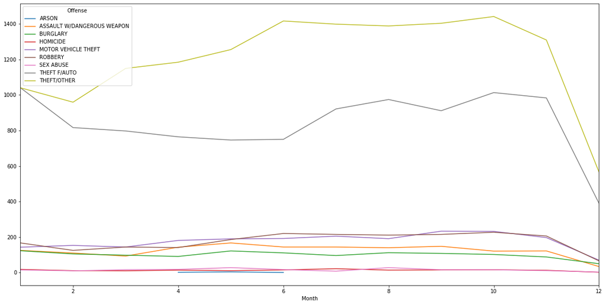

```python
month = pd.DataFrame(crime_data.groupby(['OFFENSE', 'Month']).size())
month = month.reset_index()
month.columns = ['Offense', 'Month', 'Number']

dis = month.pivot(index = 'Month', columns = 'Offense', values = 'Number')
dis.plot(figsize=(20,10))
```

In this graph, we can observe that overall, Summer(June to August) and August(September to November) has the most number of crimes. On top of this, THEFT F/AUTO and THEFT/OTHER has a higher curve than other crimes. We can see a huge decline of all kinds of crime at around November and December(Winter season). Except THEFT F/AUTO and THEFT/OTHER, the tendency of other crimes seems to be gentle. The only big decline we can see is at the times through November to December.

To better analyze this dataset, we now want to step into the data analysis with BIDs over time.

```python
crime_data.isnull().mean() * 100
```

```
CCN            0.000000
REPORT_DAT     0.000000
SHIFT          0.000000
METHOD         0.000000
OFFENSE        0.000000
BLOCK          0.000000
WARD           0.000000
LATITUDE       0.000000
LONGITUDE      0.000000
BID           79.516902
START_DATE     0.000000
END_DATE      14.245434
Month          0.000000
dtype: float64
```

The above line shows the percentage of NaN values in a columns. As we can see above, "BID" columns contains almost 80% of NaN values. In usually data analysis project, we should drop this column to avoid inaccuracy. However, in this project, BID is most commonly used way of dividing Washington D.C. in our daily life. Even though we do data visiualization on "Ward" column, most people does not know where that ward is. Therefore, here we are doing data visiualization with BID columns for the convenience. Hence, we will drop the Nan values in the crime_data dataframe.

```python
BID_crime_data = crime_data.dropna()
BID_crime_data.reset_index(drop = True).head()
```

|  | CCN | REPORT_DAT | SHIFT | METHOD | OFFENSE | BLOCK | WARD | LATITUDE | LONGITUDE | BID | START_DATE | END_DATE | Month |
| --- | --- | --- | --- | --- | --- | --- | --- | --- | --- | --- | --- | --- | --- |
| 0 | 19185228 | 2019-10-16 18:37:44 | EVENING | OTHERS | THEFT F/AUTO | 700 - 799 BLOCK OF D STREET SE | 6 | 38.883746 | -76.995586 | CAPITOL HILL | 2019-10-16 13:30:35 | 2019-10-16 16:30:55 | 10.0 |
| 1 | 19185244 | 2019-10-16 21:36:25 | EVENING | GUN | ASSAULT W/DANGEROUS WEAPON | 1 - 99 BLOCK OF PATTERSON STREET NE | 6 | 38.906447 | -77.007402 | NOMA | 2019-10-16 16:13:43 | 2019-10-16 19:11:51 | 10.0 |
| 2 | 19185309 | 2019-10-16 20:27:34 | EVENING | OTHERS | THEFT F/AUTO | 300 - 399 BLOCK OF D STREET NE | 6 | 38.894781 | -77.001314 | CAPITOL HILL | 2019-10-16 18:37:22 | 2019-10-16 19:48:57 | 10.0 |
| 3 | 19185338 | 2019-10-16 21:00:46 | EVENING | OTHERS | THEFT F/AUTO | 800 - 899 BLOCK OF POTOMAC AVENUE SE | 6 | 38.876665 | -76.994537 | CAPITOL RIVERFRONT | 2019-10-16 10:00:42 | 2019-10-16 19:14:30 | 10.0 |
| 4 | 19185375 | 2019-10-16 22:09:03 | EVENING | OTHERS | THEFT F/AUTO | 800 - 899 BLOCK OF 8TH STREET NW | 2 | 38.900337 | -77.022953 | DOWNTOWN | 2019-10-16 19:19:05 | 2019-10-16 20:57:17 | 10.0 |

We should start from counting the total number of crimes in each BID to see which district have the most crime rate, and do further analysis on that BID.

Here, we use seaborn's countplot to count the frequencies of each BID and conbines them into a barplot. We edited the font size and the figure size for readbility of the texts.

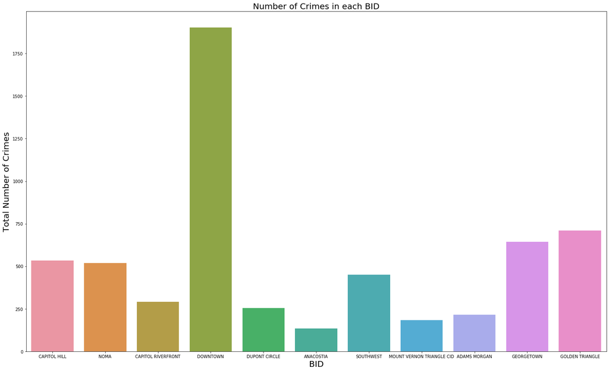

```python
plt.figure(figsize=(25, 15))

BID = sns.countplot(x = "BID", data = BID_crime_data).set_title('Number of Crimes in each BID', fontsize = 20)
plt.xlabel("BID", fontsize = 20)
plt.ylabel("Total Number of Crimes", fontsize = 20)
```

From the chart above, we discovered that the number of crimes in **Washington D.C. Downtown** is dramatically greater than all other districts. Washington D.C. Downtown has over 1750 crimes in 2019 while the highest number in other districts do not even excceeds 750. This is expected because Downtown area indeed have the most flow rate of population among all other districits.

Therefore, we hence move on to data analysis of BID Washington D.C. Downtown to see what kind of crime happens the most in Washington D.C. Downtown.

[figure not shown]

```python
downtown_crime = crime_data[crime_data.BID == 'DOWNTOWN']
downtown_crime.reset_index(drop = True)

plt.figure(figsize=(25, 15))
sns.countplot(x = "OFFENSE", data = BID_crime_data).set_title("Number of Crimes of each type in BID-Downtown",\
                                                              fontsize = 20)
plt.xlabel("Types of Crimes", fontsize = 20)
plt.ylabel("Total Number of Crimes/Each type", fontsize = 20)
```

To analyze THEFT/OTHER and THEFT F/AUTO, one way to do it is to analyze them within different times of a day. Here, we created a new dataframe with only OFFENSE of THEFT/OTHER and THEFT F/AUTO. We reseted the index for convenience. Then, we created another dataframe with 24 rows from 0 to 23. This represents the 24 hours in a day. THEFT/OTHER and THEFT F/AUTO columns means the frequencies of those crimes in that certain time frame.

**Note**: When we say "<1:00:00", it means an hour before 1AM. So, it is the time between 0:00:00 to 0:59:59. In this way we divide a day to 24 parts.

Finally, make this new table into a line plot to better see the trend.

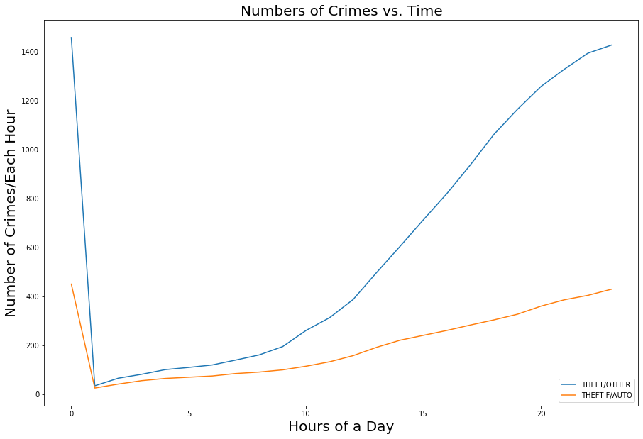

```python
downtown_theft = downtown_crime.loc[(downtown_crime['OFFENSE'] == 'THEFT/OTHER') | \
                                    (downtown_crime['OFFENSE'] == 'THEFT F/AUTO')]
# df.loc[(df['column_name'] >= A) & (df['column_name'] <= B)]
downtown_theft.reset_index(drop = True)

time = np.arange(24)
listofzeros = [0] * 24
new = pd.DataFrame({'Times':time, 'THEFT/OTHER':listofzeros, 'THEFT F/AUTO':listofzeros})

zero = datetime.strptime('23:59:59', '%H:%M:%S').time()
one = datetime.strptime('1:00:00', '%H:%M:%S').time()
two = datetime.strptime('2:00:00', '%H:%M:%S').time()
three = datetime.strptime('3:00:00', '%H:%M:%S').time()
four = datetime.strptime('4:00:00', '%H:%M:%S').time()
five = datetime.strptime('5:00:00', '%H:%M:%S').time()
six = datetime.strptime('6:00:00', '%H:%M:%S').time()
seven = datetime.strptime('7:00:00', '%H:%M:%S').time()
eight = datetime.strptime('8:00:00', '%H:%M:%S').time()
nine = datetime.strptime('9:00:00', '%H:%M:%S').time()
ten = datetime.strptime('10:00:00', '%H:%M:%S').time()
eleven = datetime.strptime('11:00:00', '%H:%M:%S').time()
twelve = datetime.strptime('12:00:00', '%H:%M:%S').time()
thirteen = datetime.strptime('13:00:00', '%H:%M:%S').time()
fourteen = datetime.strptime('14:00:00', '%H:%M:%S').time()
fifteen = datetime.strptime('15:00:00', '%H:%M:%S').time()
sixteen = datetime.strptime('16:00:00', '%H:%M:%S').time()
seventeen = datetime.strptime('17:00:00', '%H:%M:%S').time()
eighteen = datetime.strptime('18:00:00', '%H:%M:%S').time()
nineteen = datetime.strptime('19:00:00', '%H:%M:%S').time()
twenty = datetime.strptime('20:00:00', '%H:%M:%S').time()
twentyone = datetime.strptime('21:00:00', '%H:%M:%S').time()
twentytwo = datetime.strptime('22:00:00', '%H:%M:%S').time()
twentythree = datetime.strptime('23:00:00', '%H:%M:%S').time()

for index, row in downtown_theft.iterrows():
    if row['START_DATE'].time() < one:
        if row['OFFENSE'] == 'THEFT/OTHER':
            new.iloc[1]['THEFT/OTHER'] = new.iloc[1]['THEFT/OTHER'] + 1
        else: new.iloc[1]['THEFT F/AUTO'] = new.iloc[1]['THEFT F/AUTO'] + 1
    if row['START_DATE'].time() < two:
        if row['OFFENSE'] == 'THEFT/OTHER':
            new.iloc[2]['THEFT/OTHER'] = new.iloc[2]['THEFT/OTHER'] + 1
        else: new.iloc[2]['THEFT F/AUTO'] = new.iloc[2]['THEFT F/AUTO'] + 1
    if row['START_DATE'].time() < three:
        if row['OFFENSE'] == 'THEFT/OTHER':
            new.iloc[3]['THEFT/OTHER'] = new.iloc[3]['THEFT/OTHER'] + 1
        else: new.iloc[3]['THEFT F/AUTO'] = new.iloc[3]['THEFT F/AUTO'] + 1
    if row['START_DATE'].time() < four:
        if row['OFFENSE'] == 'THEFT/OTHER':
            new.iloc[4]['THEFT/OTHER'] = new.iloc[4]['THEFT/OTHER'] + 1
        else: new.iloc[4]['THEFT F/AUTO'] = new.iloc[4]['THEFT F/AUTO'] + 1
    if row['START_DATE'].time() < five:
        if row['OFFENSE'] == 'THEFT/OTHER':
            new.iloc[5]['THEFT/OTHER'] = new.iloc[5]['THEFT/OTHER'] + 1
        else: new.iloc[5]['THEFT F/AUTO'] = new.iloc[5]['THEFT F/AUTO'] + 1
    if row['START_DATE'].time() < six:
        if row['OFFENSE'] == 'THEFT/OTHER':
            new.iloc[6]['THEFT/OTHER'] = new.iloc[6]['THEFT/OTHER'] + 1
        else: new.iloc[6]['THEFT F/AUTO'] = new.iloc[6]['THEFT F/AUTO'] + 1
    if row['START_DATE'].time() < seven:
        if row['OFFENSE'] == 'THEFT/OTHER':
            new.iloc[7]['THEFT/OTHER'] = new.iloc[7]['THEFT/OTHER'] + 1
        else: new.iloc[7]['THEFT F/AUTO'] = new.iloc[7]['THEFT F/AUTO'] + 1
    if row['START_DATE'].time() < eight:
        if row['OFFENSE'] == 'THEFT/OTHER':
            new.iloc[8]['THEFT/OTHER'] = new.iloc[8]['THEFT/OTHER'] + 1
        else: new.iloc[8]['THEFT F/AUTO'] = new.iloc[8]['THEFT F/AUTO'] + 1
    if row['START_DATE'].time() < nine:
        if row['OFFENSE'] == 'THEFT/OTHER':
            new.iloc[9]['THEFT/OTHER'] = new.iloc[9]['THEFT/OTHER'] + 1
        else: new.iloc[9]['THEFT F/AUTO'] = new.iloc[9]['THEFT F/AUTO'] + 1
    if row['START_DATE'].time() < ten:
        if row['OFFENSE'] == 'THEFT/OTHER':
            new.iloc[10]['THEFT/OTHER'] = new.iloc[10]['THEFT/OTHER'] + 1
        else: new.iloc[10]['THEFT F/AUTO'] = new.iloc[10]['THEFT F/AUTO'] + 1
    if row['START_DATE'].time() < eleven:
        if row['OFFENSE'] == 'THEFT/OTHER':
            new.iloc[11]['THEFT/OTHER'] = new.iloc[11]['THEFT/OTHER'] + 1
        else: new.iloc[11]['THEFT F/AUTO'] = new.iloc[11]['THEFT F/AUTO'] + 1
    if row['START_DATE'].time() < twelve:
        if row['OFFENSE'] == 'THEFT/OTHER':
            new.iloc[12]['THEFT/OTHER'] = new.iloc[12]['THEFT/OTHER'] + 1
        else: new.iloc[12]['THEFT F/AUTO'] = new.iloc[12]['THEFT F/AUTO'] + 1
    if row['START_DATE'].time() < thirteen:
        if row['OFFENSE'] == 'THEFT/OTHER':
            new.iloc[13]['THEFT/OTHER'] = new.iloc[13]['THEFT/OTHER'] + 1
        else: new.iloc[13]['THEFT F/AUTO'] = new.iloc[13]['THEFT F/AUTO'] + 1
    if row['START_DATE'].time() < fourteen:
        if row['OFFENSE'] == 'THEFT/OTHER':
            new.iloc[14]['THEFT/OTHER'] = new.iloc[14]['THEFT/OTHER'] + 1
        else: new.iloc[14]['THEFT F/AUTO'] = new.iloc[14]['THEFT F/AUTO'] + 1
    if row['START_DATE'].time() < fifteen:
        if row['OFFENSE'] == 'THEFT/OTHER':
            new.iloc[15]['THEFT/OTHER'] = new.iloc[15]['THEFT/OTHER'] + 1
        else: new.iloc[15]['THEFT F/AUTO'] = new.iloc[15]['THEFT F/AUTO'] + 1
    if row['START_DATE'].time() < sixteen:
        if row['OFFENSE'] == 'THEFT/OTHER':
            new.iloc[16]['THEFT/OTHER'] = new.iloc[16]['THEFT/OTHER'] + 1
        else: new.iloc[16]['THEFT F/AUTO'] = new.iloc[16]['THEFT F/AUTO'] + 1
    if row['START_DATE'].time() < seventeen:
        if row['OFFENSE'] == 'THEFT/OTHER':
            new.iloc[17]['THEFT/OTHER'] = new.iloc[17]['THEFT/OTHER'] + 1
        else: new.iloc[17]['THEFT F/AUTO'] = new.iloc[17]['THEFT F/AUTO'] + 1
    if row['START_DATE'].time() < eighteen:
        if row['OFFENSE'] == 'THEFT/OTHER':
            new.iloc[18]['THEFT/OTHER'] = new.iloc[18]['THEFT/OTHER'] + 1
        else: new.iloc[18]['THEFT F/AUTO'] = new.iloc[18]['THEFT F/AUTO'] + 1
    if row['START_DATE'].time() < nineteen:
        if row['OFFENSE'] == 'THEFT/OTHER':
            new.iloc[19]['THEFT/OTHER'] = new.iloc[19]['THEFT/OTHER'] + 1
        else: new.iloc[19]['THEFT F/AUTO'] = new.iloc[19]['THEFT F/AUTO'] + 1
    if row['START_DATE'].time() < twenty:
        if row['OFFENSE'] == 'THEFT/OTHER':
            new.iloc[20]['THEFT/OTHER'] = new.iloc[20]['THEFT/OTHER'] + 1
        else: new.iloc[20]['THEFT F/AUTO'] = new.iloc[20]['THEFT F/AUTO'] + 1
    if row['START_DATE'].time() < twentyone:
        if row['OFFENSE'] == 'THEFT/OTHER':
            new.iloc[21]['THEFT/OTHER'] = new.iloc[21]['THEFT/OTHER'] + 1
        else: new.iloc[21]['THEFT F/AUTO'] = new.iloc[21]['THEFT F/AUTO'] + 1
    if row['START_DATE'].time() < twentytwo:
        if row['OFFENSE'] == 'THEFT/OTHER':
            new.iloc[22]['THEFT/OTHER'] = new.iloc[22]['THEFT/OTHER'] + 1
        else: new.iloc[22]['THEFT F/AUTO'] = new.iloc[22]['THEFT F/AUTO'] + 1
    if row['START_DATE'].time() < twentythree:
        if row['OFFENSE'] == 'THEFT/OTHER':
            new.iloc[23]['THEFT/OTHER'] = new.iloc[23]['THEFT/OTHER'] + 1
        else: new.iloc[23]['THEFT F/AUTO'] = new.iloc[23]['THEFT F/AUTO'] + 1
    if row['START_DATE'].time() < zero:
        if row['OFFENSE'] == 'THEFT/OTHER':
            new.iloc[0]['THEFT/OTHER'] = new.iloc[0]['THEFT/OTHER'] + 1
        else: new.iloc[0]['THEFT F/AUTO'] = new.iloc[0]['THEFT F/AUTO'] + 1

plt.figure(figsize=(15, 10))
plt.plot('Times', 'THEFT/OTHER', data = new)
plt.plot('Times', 'THEFT F/AUTO', data = new)
plt.title("Numbers of Crimes vs. Time", fontsize = 20)
plt.xlabel("Hours of a Day", fontsize = 20)
plt.ylabel("Number of Crimes/Each Hour", fontsize = 20)
plt.legend()
```

## Visualizing data with Wards over Maps

Now we have some analysis based on BID, here we want to do some data analysis on a real map to better view the data. Using the folium package, we can get a map with the location at Washington D.C. Let's just do the simplest thing first. We inserted a heat map of all crimes in the crime_data dataset. The darker the color is, the more crimes there are in that area.

```python
DCmap = folium.Map(location=[38.883746, -76.99558], zoom_start=11)
DCmap.add_child(plugins.HeatMap(crime_data[['LATITUDE', 'LONGITUDE']].as_matrix(), radius = 15))
```

[interactive chart not shown]

Here, we can observe that the middle right part of the map is very red. This area approximately includes Capitol Hill, Capitol Riverfront and Downtown, in about Ward 1, Ward 2 and Ward 6. This heat map further proves our analysis above. Downtown area have the most crime rate compare to other BIDs. To better view the relationship between cirmes and Wards, we frist start by making a bar plot of Number of crimes vs. Each ward.

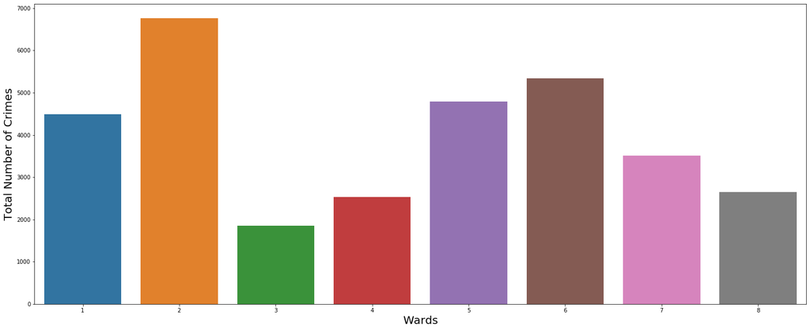

```python
plt.figure(figsize=(25, 10))
sns.countplot(x = "WARD", data = crime_data)
plt.xlabel("Wards", fontsize = 20)
plt.ylabel("Total Number of Crimes", fontsize = 20)
```

We can easily found out from this graph that Ward 1, Ward 2, Ward 5 and Ward 6 have the most number of crimes.

The code below creates a Choropleth of Folium. It contains a regional view of number of crimes. The first thing to do is to find a map overaly geojson file to overlay it on the map to display the differrent wards of Washington D.C.. We simply did a google research on key word "Washington D.C. ward geojson". Then I found a suitaible file on the Open DC Data, which is same website as where we find our database. Please view more details about Washington D.C. ward geojson file at http://data.codefordc.org/dataset/dc-wards-map-overlay. To obtain the neccessay information used in the code, we had to read our geojson file code to find out what we should put in the key_on field of Choropleth map. To do this, we found an website called geojson.io where we can dump in our geojson file and see the source code of it. Please view more details at http://geojson.io/#map=2/20.0/0.0. Finally, we have our neccessary data. Now we want to sort our database based on each ward. Below, crimedata2 is our sorted database. We want to put this dataframe into our Choropleth function and insert it on the map to view it on the map. We needed to change every ward name from for example "2" to "Ward 2" to fit with the choropleth map

```python
DCmap = folium.Map(location=[38.883746, -76.99558], zoom_start=11)

# calculating total number of incidents per district
crimedata2 = pd.DataFrame(crime_data['WARD'].value_counts().astype(float))
crimedata2 = crimedata2.reset_index()
crimedata2.columns = ['Ward', 'Number']

for index, row in crimedata2.iterrows():
    if row['Ward'] == 1:
        crimedata2.loc[index, 'Ward'] = "Ward 1"
    elif row['Ward'] == 2:
        crimedata2.loc[index, 'Ward'] = "Ward 2"
    elif row['Ward'] == 3:
        crimedata2.loc[index, 'Ward'] = "Ward 3"
    elif row['Ward'] == 4:
        crimedata2.loc[index, 'Ward'] = "Ward 4"
    elif row['Ward'] == 5:
        crimedata2.loc[index, 'Ward'] = "Ward 5"
    elif row['Ward'] == 6:
        crimedata2.loc[index, 'Ward'] = "Ward 6"
    elif row['Ward'] == 7:
        crimedata2.loc[index, 'Ward'] = "Ward 7"
    else: crimedata2.loc[index, 'Ward'] = "Ward 8"


# Creation of Choropleth
ward_geo = r'dc-ward-map-overlay.geojson'

folium.Choropleth(
    geo_data=ward_geo,
    name='Choropleth',
    data=crimedata2,
    columns=['Ward', 'Number'],
    key_on='feature.properties.name',
    fill_color='YlGn',
    fill_opacity=0.7,
    line_opacity=0.2,
    legend_name='Number of Crimes'
).add_to(DCmap)

folium.LayerControl().add_to(DCmap)
DCmap
```

[interactive chart not shown]

The above map is a better visualiaztion of the bar plot of Total number of crimes vs. Wards. As we get more closer to the center of Washington D.C. the color gets darker.

## Visualization data with Method

In this section, we will be analyzing the crime_data set within its "METHOD" columns. Method is the way that the suspect used when they did a crime. For example in our dataset, method can be either GUN, KNIFE or OTHERS. Others means it is either not defined or it is hard to say in one word. The representative weapons would be guns and knives.

In the pie chart below, we did a simple analyza on the percentage of the use of guns, the use of knives and the use of others. We can see that over 80 percentage of the pie chart belongs to OTHERS. The interesting thing is that guns have more percentage than knives. In our expectation, suspects should be using more knives than guns since it is simplier to get and easier to use. However, since gun control is always a problem in US, this is not surprising though.

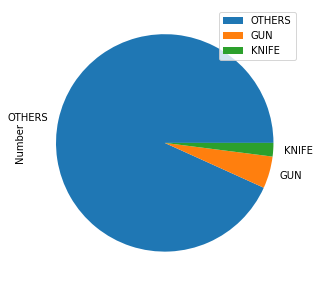

```python
crimedata3 = pd.DataFrame(crime_data['METHOD'].value_counts().astype(float))
crimedata3 = crimedata3.reset_index()
crimedata3.columns = ['Method', 'Number']
crimedata3 = crimedata3.set_index('Method')

plot = crimedata3.plot.pie(y='Number', figsize=(5, 5))
```

# 3. Predicting homicide offense given time

In this part of the tutorial, we will try to predict whether the type of offense a person encounter is homicide given a specific time during a day, if the person encountered a crime. The reason we choose homicide is because it is pretty much the most dangerous and violent crimes among all crimes. With this prediction, one can be more aware about when will those dangerous offense occur during a day and thus be more aware when traveling during this time or to adjust schedules accrodingly. There are no linear relationship between the prediction variable and the response variable, therefore we cannot use any linear model. So we choose to use Random Forest Model.

## Predicting Homicide

```python
# In order to build the model predicting possibility of homicide, we add a catagorical variable is_homicide to diffrenciate
# between crimes that are Homicide and crimes that are not.
is_homicide = []
for index, row in crime_data.iterrows():
    if row['OFFENSE'] == 'HOMICIDE':
        is_homicide.append(1)
    else:
        is_homicide.append(0)

crime_data['is_homicide'] = is_homicide

# We need to convert start_date from timestamp variable to numerical variable as well. We achieve this by converting the
# time as seconds from 00:00
start_time = []
for index, row in crime_data.iterrows():
    time = row['START_DATE'].time()
    seconds = time.hour * 3600 + time.minute * 60 + time.second
    start_time.append(seconds)

crime_data['start_time'] = start_time

# assign columns with x and y
x = crime_data[['start_time', 'LATITUDE', 'LONGITUDE']]
y = crime_data[['is_homicide']]

# split the data into train and test
from sklearn.model_selection import train_test_split
x_train, x_test, y_train, y_test = train_test_split(x, y, test_size=0.2, random_state=7)

# fit a random forest model to our data
from sklearn.ensemble import RandomForestClassifier
clf = RandomForestClassifier()
clf.fit(x_train, y_train)

# This is the accuracy of the random forest model
print('The accuracy of our model is:' + str(clf.score(x_test, y_test)))
```

```
The accuracy of our model is:0.9965538847117794
```

One thing to note about the result of this model is that even though the accuracy score is high, it might just be because there are little incidents of homicide. Therefore even if we predict every offense encountered as not homicide, we would still get a pretty good score. To see whether or not it is the case, we can calculate the accuracy of predicting every offense encountered as not homicide as follows:

```python
percent_homicide = y_test[y_test['is_homicide'] == 1].shape[0] / x_test.shape[0]
1 - percent_homicide
```

```
0.9962406015037594
```

```python
# loss of failing to predict an actual homicide = 100,  falsely predict a non-homicide = 1
y_pred = clf.predict(x_test)
y_test.reindex()
loss = 0
i = 0
for index, row in y_test.iterrows():
    if row['is_homicide'] == 1 and y_pred[i] == 0:
        loss = loss + 100
    elif row['is_homicide'] == 0 and y_pred[i] == 1:
        loss = loss + 1
    i = i + 1
print("Loss of Random Forest Model: " + str(loss))
print("Loss of predicting all incident as non-homicide: " + str(y_test[y_test['is_homicide'] == 1].shape[0] * 100))
```

```
Loss of Random Forest Model: 2200
Loss of predicting all incident as non-homicide: 2400
```

As we can see, our model is slightly better than predicting all incident as non-homicide, which still makes the model pretty bad. One reason for this might be because the chance of homicide occuring in an offense is too low and the correlation between homicide and time and location is not high enough.

# 4. Conclusion

In our model, even though the model is very precise. However, because of the lack of correlations of the dataset, we cannot say this is a very efficient and good model. This is worth exploring though. There are still many things we did not cover in our project for other people to explore.